# Linear model in INLA

# Running a simple linear model in INLA

```r
library(tidyverse)
library(INLA)
bu<-read_csv("template_BU.csv")
head(bu)
```

| X1 | Lat | Long | TOT_POP | BU_TOT | FID | MeanTemp | Precip_mm | MeanFCPerc | StdDevFCPerc | FLOSS_ha | FGAIN_ha | Forest | Agric | ShrGra | Urb | Water | MeanNDVI | SdNDVI |
| --- | --- | --- | --- | --- | --- | --- | --- | --- | --- | --- | --- | --- | --- | --- | --- | --- | --- | --- |
| 1 | 6.383333 | 2.348333 | 153447 | 0 | 140 | 27.2 | 1201 | 4.056050 | 5.335444 | 5.581306 | 0.0000000 | 0.24 | 0.17 | 0.06 | 0.45 | 0.09 | 0.2209703 | 0.13231286 |
| 2 | 6.818060 | 1.637500 | 2528 | 0 | 192 | 27.2 | 1035 | 13.912665 | 3.920355 | 12.211678 | 2.0642684 | 0.02 | 0.33 | 0.65 | 0.00 | 0.00 | 0.2861486 | 0.13359679 |
| 3 | 6.840560 | 1.670830 | 10691 | 2 | 9 | 27.0 | 1048 | 12.317504 | 3.076835 | 5.545661 | 2.1748920 | 0.02 | 0.04 | 0.94 | 0.00 | 0.00 | 0.2953299 | 0.11664001 |
| 4 | 6.974720 | 1.673890 | 1287 | 2 | 84 | 26.5 | 1096 | 14.576509 | 4.493725 | 10.851241 | 0.0000000 | 0.00 | 0.04 | 0.96 | 0.00 | 0.00 | 0.2542900 | 0.15961795 |
| 5 | 6.946390 | 1.688330 | 2094 | 2 | 106 | 27.0 | 1068 | 12.634015 | 5.882964 | 20.135695 | 0.9763485 | 0.00 | 0.02 | 0.98 | 0.00 | 0.00 | 0.2868261 | 0.12407618 |
| 6 | 6.947220 | 1.709720 | 3444 | 2 | 131 | 26.7 | 1088 | 9.379451 | 4.455143 | 5.048105 | 0.0000000 | 0.00 | 0.01 | 0.99 | 0.00 | 0.00 | 0.1882990 | 0.09662024 |

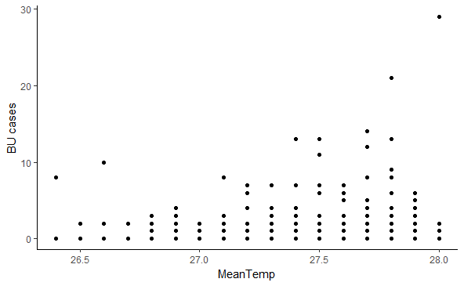

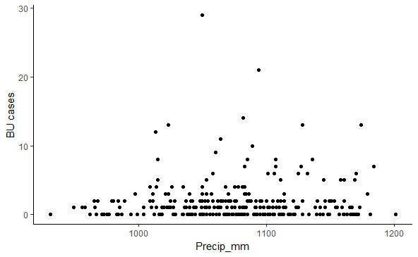

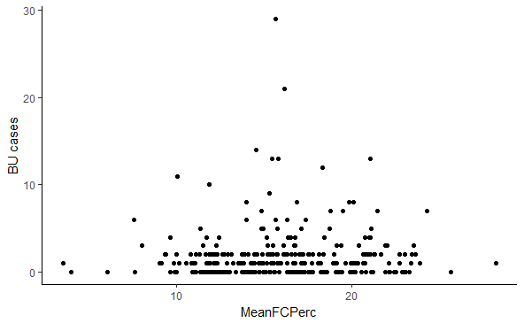

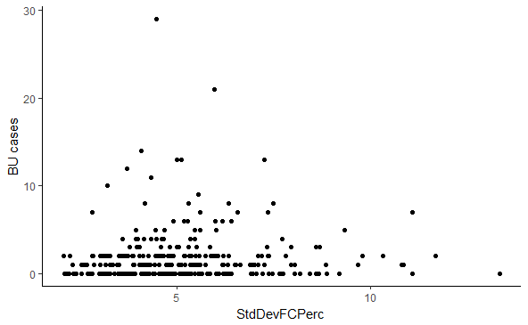

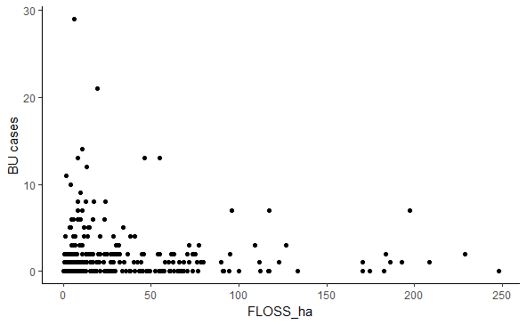

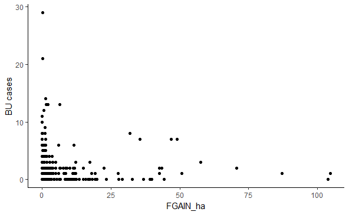

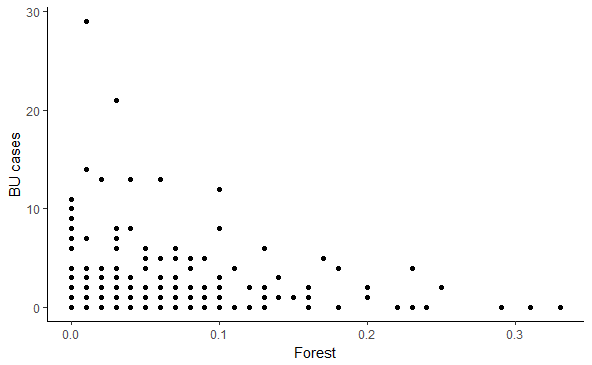

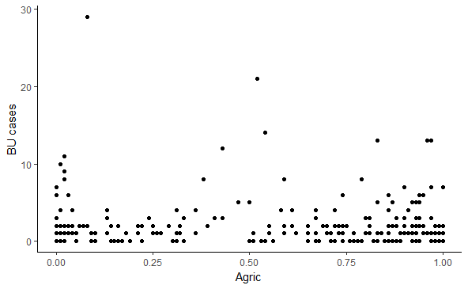

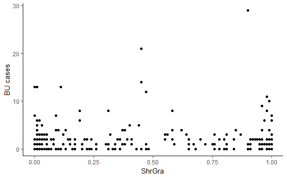

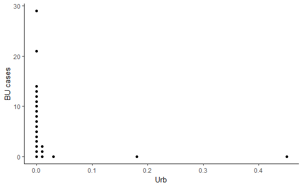

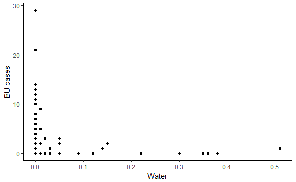

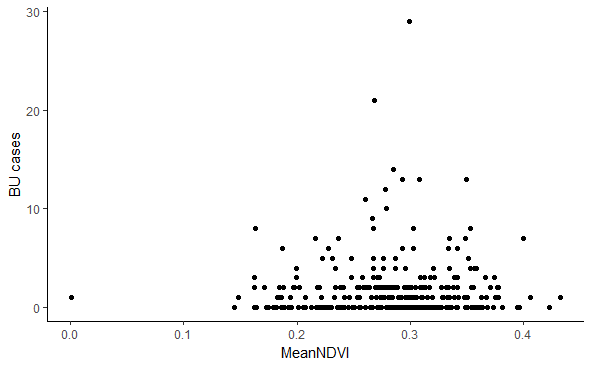

[1 more figures not shown]

```r
#plot total BU cases by each variable to see whether there is any relationsip
for(i in 7:ncol(bu)){
  varname<-names(bu)[i]
  print(ggplot(bu)+geom_point(aes(bu[i], BU_TOT))+xlab(varname)+ylab("BU cases")+theme_classic())
}
```

POssible relationships between forest cover and NDVI and BU cases, no relationship with urban or water, so dont use those. Maybe best to just use either agriculture or forest cover from th eland cover classes

What we should do: Plot the data, check whether interactions are possible etc….but no time.

First linear model as per lm (note that this WOULD NOT be the way to start analysing this data but we use it here solely to begin exploring INLA)

```r
summary(lm1<-lm(log(BU_TOT+1)~TOT_POP+ Forest + Precip_mm , data = bu))
```

```
Call:
lm(formula = log(BU_TOT + 1) ~ TOT_POP + Forest + Precip_mm,
    data = bu)

Residuals:
     Min       1Q   Median       3Q      Max
-0.79923 -0.73887 -0.05573  0.35418  2.67049

Coefficients:
              Estimate Std. Error t value Pr(>|t|)
(Intercept)  2.658e-01  8.923e-01   0.298   0.7660
TOT_POP     -1.329e-06  6.794e-07  -1.956   0.0515 .
Forest       7.816e-02  7.313e-01   0.107   0.9150
Precip_mm    4.574e-04  8.211e-04   0.557   0.5779
---
Signif. codes:  0 ‘***’ 0.001 ‘**’ 0.01 ‘*’ 0.05 ‘.’ 0.1 ‘ ’ 1

Residual standard error: 0.7288 on 291 degrees of freedom
Multiple R-squared:  0.01346,   Adjusted R-squared:  0.003292
F-statistic: 1.324 on 3 and 291 DF,  p-value: 0.2668
```

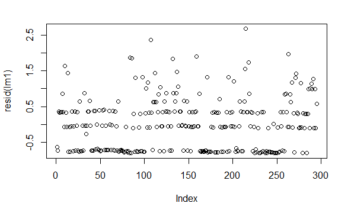

```r
plot(resid(lm1))
```

Now we will do the same thing in INLA

First, what is our model?

Bu_pos ~ N(mu, sigma2) E(Bu_pos) = mu Var(Bu_pos) = sigma2 (ie the noise, epsilon) mu = B0 + B1*TOT_POP + B2*FOREST + B3*Precip_mm

```r
bu$BU_TOT.l<-log(bu$BU_TOT+1)
I1 <- inla(BU_TOT.l ~ TOT_POP+ Forest + Precip_mm,
           data = bu,
           family = "gaussian")
summary(I1)
```

```
Call:
c("inla(formula = BU_TOT.l ~ TOT_POP + Forest + Precip_mm, family = \"gaussian\", ",  "    data = bu)")

Time used:
 Pre-processing    Running inla Post-processing           Total
         4.8779          1.6714          0.2703          6.8196

Fixed effects:
              mean     sd 0.025quant 0.5quant 0.975quant   mode kld
(Intercept) 0.2658 0.8924    -1.4876   0.2658     2.0176 0.2658   0
TOT_POP     0.0000 0.0000     0.0000   0.0000     0.0000 0.0000   0
Forest      0.0781 0.7312    -1.3585   0.0781     1.5134 0.0781   0
Precip_mm   0.0005 0.0008    -0.0012   0.0005     0.0021 0.0005   0

The model has no random effects

Model hyperparameters:
                                         mean     sd 0.025quant
Precision for the Gaussian observations 1.896 0.1545      1.606
                                        0.5quant 0.975quant  mode
Precision for the Gaussian observations    1.891      2.212 1.883

Expected number of effective parameters(std dev): 4.003(3e-04)
Number of equivalent replicates : 73.70

Marginal log-Likelihood:  -368.38
```

```r
I1$summary.fixed
```

|  | mean | sd | 0.025quant | 0.5quant | 0.975quant | mode | kld |
| --- | --- | --- | --- | --- | --- | --- | --- |
| (Intercept) | 2.658057e-01 | 8.923973e-01 | -1.487600e+00 | 2.657802e-01 | 2.017606e+00 | 2.658055e-01 | 4.513133e-13 |
| TOT_POP | -1.328701e-06 | 6.795119e-07 | -2.663824e-06 | -1.328721e-06 | 5.199147e-09 | -1.328701e-06 | 4.511440e-13 |
| Forest | 7.811615e-02 | 7.311537e-01 | -1.358473e+00 | 7.809548e-02 | 1.513390e+00 | 7.811659e-02 | 4.505076e-13 |
| Precip_mm | 4.574071e-04 | 8.211964e-04 | -1.156101e-03 | 4.573838e-04 | 2.069438e-03 | 4.574073e-04 | 4.521574e-13 |

```r
I1$summary.hyper
```

|  | mean | sd | 0.025quant | 0.5quant | 0.975quant | mode |
| --- | --- | --- | --- | --- | --- | --- |
| Precision for the Gaussian observations | 1.896022 | 0.1544829 | 1.605759 | 1.89147 | 2.212281 | 1.882665 |

```r
round(I1$summary.fixed[, c("mean",
                              "0.025quant",
                              "0.975quant")],2)
```

|  | mean | 0.025quant | 0.975quant |
| --- | --- | --- | --- |
| (Intercept) | 0.27 | -1.49 | 2.02 |
| TOT_POP | 0.00 | 0.00 | 0.00 |
| Forest | 0.08 | -1.36 | 1.51 |
| Precip_mm | 0.00 | 0.00 | 0.00 |

Looking at the output

First you get information about hte time used for running the model - useful for sptial models that can take a while.

You can access the entire distribution rather than just extrating the mean and the quantiles, and then plot this

```r
beta2 <- I1$marginals.fixed$Forest
beta2
```

```
                 x            y
 [1,] -7.233425877 2.107217e-20
 [2,] -5.771117473 1.013784e-13
 [3,] -4.308809068 1.977275e-08
 [4,] -3.806993509 6.766856e-07
 [5,] -3.577654866 3.020642e-06
 [6,] -3.458166650 6.387906e-06
 [7,] -3.086043013 5.734009e-05
 [8,] -2.846500664 2.102110e-04
 [9,] -2.669099311 5.186116e-04
[10,] -2.348829363 2.323507e-03
[11,] -2.197070746 4.453644e-03
[12,] -2.115346461 6.220503e-03
[13,] -1.814722691 1.925104e-02
[14,] -1.629477306 3.568358e-02
```

[output cut: 61 more lines]

```r
head(beta2)
```

```
             x            y
[1,] -7.233426 2.107217e-20
[2,] -5.771117 1.013784e-13
[3,] -4.308809 1.977275e-08
[4,] -3.806994 6.766856e-07
[5,] -3.577655 3.020642e-06
[6,] -3.458167 6.387906e-06
```

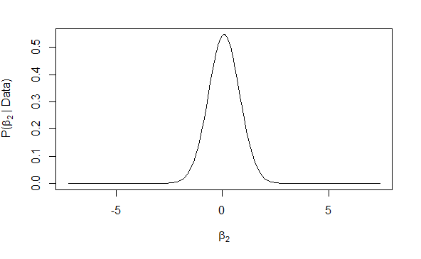

```r
plot(x = beta2[,1],y = beta2[,2],type = "l",xlab = expression(beta[2]),ylab = expression(paste("P(", beta[2] ," | Data)")))
```

Normally distributed (what we assume distribution of betas to be)

You can also use inla.qmarginal or inla.zmarginal to extract more qunatiles for specific betas (eg inla.zmarginal(beta2)) will return more quantiles for beta2

For non normal distributions it is also useful to consider the interval within which 95% of the density lies:

```r
inla.hpdmarginal(0.95, beta2)
```

```
                 low     high
level:0.95 -1.357619 1.509549
```

There is no significant effect of forest cover on BU cases. Remember how shocking the residuals looked however - this is count data and we have logged it, plus there are clear patterns still.

What about the information on the precision? Inla works with precision, tau, which = 1 / sigma^2

need to convert back from tau, to sigma

INLA has a support function which will do this: need to use inla.emarginal on tau with a square root if you want the distribution you use inla.tmarginal

```r
invsqrt <- function(x) {1 / sqrt(x) }
tau<- I1$marginals.hyperpar$`Precision for the Gaussian observations`
inla.emarginal(fun = invsqrt,marg = tau)
```

```
[1] 0.7281604
```

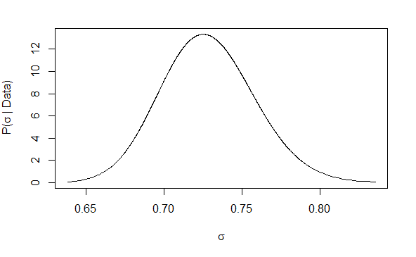

```r
sigma_dist<-inla.tmarginal(fun = invsqrt, marg = tau)
plot(x = sigma_dist[,1], y = sigma_dist[,2],type = "l",xlab = expression(sigma),  ylab = expression(paste("P(", sigma ," | Data)")))
```

This was our sigma, and you can plot the distribution as well

If you want to have fitted values, you need to tell inla this. This is necessary if you want to calculate residuals and predictions. This is done through the control.predictor command

```r
I2 <- inla(BU_TOT.l ~ TOT_POP+ Forest + Precip_mm,
           control.predictor = list(compute = TRUE),
           data = bu,
           family = "gaussian")
Fit2 <- I2$summary.fitted.values[,"mean"]
head(Fit2)
```

```
[1] 0.6300032 0.7374158 0.7325289 0.7654168 0.7515373 0.7588916
```

Now you can calculate the residuals and do the same plot as we performed on the LM To do this, subtract the fitted values from the observed data, and this is your E

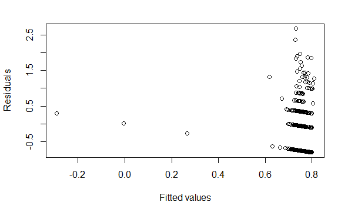

```r
  E2 <- bu$BU_TOT.l - Fit2
plot(x = Fit2,
     y = E2,
     xlab = "Fitted values",
     ylab = "Residuals")
```

Uh oh!

There are of course a whole load of different model checks you should now run. We will skip because of time

Finally, model selection is done using the DIC

To calculate the DIC Again, need to set it as an option in the inla function

```r
I3 <- inla(BU_TOT.l ~ TOT_POP+ Forest + Precip_mm,
           control.predictor = list(compute = TRUE),
           control.compute = list(dic = TRUE),
           data = bu,
           family = "gaussian")
I3$dic$dic
```

```
[1] 656.6135
```

Finally, lets predict from our model! Our terrible model…

First, we can predict from the lm using the “by hand” approach rather than predict

We do this because there is no predict() for INLA so need to do it by hand

```r
# Create hte new dataset
newdat<-data.frame(TOT_POP = rep(mean(bu$TOT_POP),100), Forest = seq(from = min(bu$Forest), to = max(bu$Forest),length.out = 100),Precip_mm = rep(mean(bu$Precip_mm),100))
# convertto a design matrix.
X    <- model.matrix(~ TOT_POP + Forest + Precip_mm, data = newdat)
beta <- coef(lm1)
# Now we can calculate fitted values and SEs:
FittedVals <- X %*% beta
SES <- sqrt(diag(X %*% vcov(lm1) %*% t(X)))
newdat$mu    <- FittedVals               #Fitted values
newdat$selow <- FittedVals - 1.96 * SES #Lower bound
newdat$seup  <- FittedVals + 1.96 * SES #Upper bound
head(newdat)
```

|  | TOT_POP | Forest | Precip_mm | mu | selow | seup |
| --- | --- | --- | --- | --- | --- | --- |
| 1 | 11286.19 | 0.000000000 | 1076.108 | 0.7430276 | 0.6408966 | 0.8451587 |
| 2 | 11286.19 | 0.003333333 | 1076.108 | 0.7432882 | 0.6438537 | 0.8427226 |
| 3 | 11286.19 | 0.006666667 | 1076.108 | 0.7435487 | 0.6466502 | 0.8404472 |
| 4 | 11286.19 | 0.010000000 | 1076.108 | 0.7438092 | 0.6492731 | 0.8383454 |
| 5 | 11286.19 | 0.013333333 | 1076.108 | 0.7440698 | 0.6517091 | 0.8364304 |
| 6 | 11286.19 | 0.016666667 | 1076.108 | 0.7443303 | 0.6539447 | 0.8347158 |

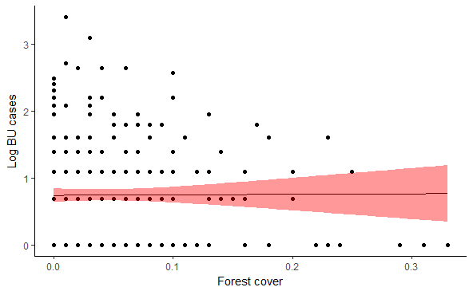

```r
# Or use: predict(M8, newdata = MyData, se = TRUE)
ggplot()+geom_point(data = bu, aes( Forest, BU_TOT.l)) +
  xlab("Forest cover")+ylab("Log BU cases") +
  geom_line(data = newdat, aes(Forest, mu )) +
  geom_ribbon(data = newdat, aes(Forest, ymax = seup, ymin = selow), fill = "red", alpha = 0.4) +
  theme_classic()
```

As suspected - this model is very awful at predicting!

What about from R-INLA?

Two methods:

1, take advantage of the fact that if R-INLA sees an NA it will predict for that variable 2, use the r inla function make.lincombs

Method 1: Make a load of extra rows that are NAs and inla will predict them

```r
#create a new dataset which includes a load of nas for our variable of interest
newdat2<-data.frame(TOT_POP = rep(mean(bu$TOT_POP),100), Forest = seq(from = min(bu$Forest), to = max(bu$Forest),length.out = 100),Precip_mm = rep(mean(bu$Precip_mm),100),BU_TOT.l = rep(NA, 100))
#combine with the orginal data
bu%>%select(TOT_POP, Forest, Precip_mm, BU_TOT.l)%>%bind_rows(newdat2)->comb.data
#rerun the model
I4 <- inla(BU_TOT.l ~ TOT_POP + Forest,
            control.predictor = list(
                      compute = TRUE,
                      quantiles = c(0.025, 0.975)),
            data = comb.data)
I4$summary.fitted.values
```

|  | mean | sd | 0.025quant | 0.975quant | mode |
| --- | --- | --- | --- | --- | --- |
| fitted.Predictor.001 | 0.55681078 | 0.17320225 | 0.2169378 | 0.8965252 | 0.55681367 |
| fitted.Predictor.002 | 0.75818090 | 0.04538952 | 0.6691140 | 0.8472069 | 0.75818159 |
| fitted.Predictor.003 | 0.74764089 | 0.04504711 | 0.6592457 | 0.8359952 | 0.74764171 |
| fitted.Predictor.004 | 0.76036748 | 0.05185372 | 0.6586158 | 0.8620721 | 0.76036842 |
| fitted.Predictor.005 | 0.75932422 | 0.05179269 | 0.6576922 | 0.8609091 | 0.75932516 |
| fitted.Predictor.006 | 0.75757899 | 0.05170329 | 0.6561224 | 0.8589886 | 0.75757993 |
| fitted.Predictor.007 | 0.76067595 | 0.05187247 | 0.6588874 | 0.8624173 | 0.76067696 |
| fitted.Predictor.008 | 0.76022140 | 0.05184483 | 0.6584871 | 0.8619086 | 0.76022234 |
| fitted.Predictor.009 | 0.75941903 | 0.05179827 | 0.6577762 | 0.8610149 | 0.75941992 |
| fitted.Predictor.010 | 0.75554254 | 0.05161861 | 0.6542520 | 0.8567859 | 0.75554364 |

[output cut: 385 more lines]

```r
nrow(I4$summary.fitted.values) == nrow(comb.data)
```

```
[1] TRUE
```

Now have fitted values for the original data AND the new, predicted data We can now extract these and plot

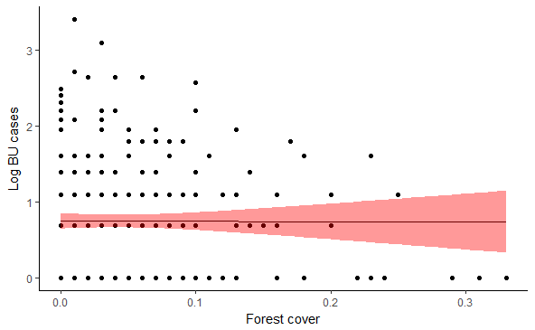

```r
FIT <- I4$summary.fitted.values[296:395,] #the 100 extra roes we added
# And add the relevant pieces to MyData
newdat2$mu    <- FIT[,"mean"]       #Fitted values
newdat2$selow <- FIT[,"0.025quant"] #Lower bound
newdat2$seup  <- FIT[,"0.975quant"] #Upper bound
ggplot()+geom_point(data = bu, aes( Forest, BU_TOT.l)) +
  xlab("Forest cover")+ylab("Log BU cases") +
  geom_line(data = newdat2, aes(Forest, mu )) +
  geom_ribbon(data = newdat2, aes(Forest, ymax = seup, ymin = selow), fill = "red", alpha = 0.4) +
  theme_classic()
```

Method 2. make.lincombs version

Previously we added extra data, but INLA also has helper functions to calculate linear combinations - inla.make.lincombs. This should produce similar (although not necessarily the same) results.

First wwe create a grid of covariates, then make a design matrix using the model.matrix function run the model with the inla.make.lincombs function visualise the results

```r
newdat3<-data.frame(TOT_POP = rep(mean(bu$TOT_POP),100), Forest = seq(from = min(bu$Forest), to = max(bu$Forest),length.out = 100),Precip_mm = rep(mean(bu$Precip_mm),100))
# convertto a design matrix.
X    <- model.matrix(~ TOT_POP + Forest + Precip_mm, data = newdat)
X<-as.data.frame(X)
lincomb <- inla.make.lincombs(X)
#rerun inla with the make.lincombs included
I4b <- inla(BU_TOT.l ~ TOT_POP + Forest + Precip_mm,
           lincomb = lincomb,
           control.inla = list(
                 lincomb.derived.only = FALSE),
           control.predictor = list(
                  compute = TRUE,
                  quantiles = c(0.025, 0.975)),
           data = bu)
# The relevant output is now in: $summary.lincomb
head(I4b$summary.lincomb)
```

|  | ID | mean | sd | 0.025quant | 0.5quant | 0.975quant | mode | kld |
| --- | --- | --- | --- | --- | --- | --- | --- | --- |
| lc001 | 1 | 0.7430298 | 0.05210983 | 0.6406431 | 0.7430284 | 0.8453229 | 0.7430298 | 4.292991e-13 |
| lc002 | 2 | 0.7432902 | 0.05073444 | 0.6436059 | 0.7432888 | 0.8428833 | 0.7432902 | 4.528908e-13 |
| lc003 | 3 | 0.7435506 | 0.04944100 | 0.6464076 | 0.7435491 | 0.8406046 | 0.7435506 | 4.768972e-13 |
| lc004 | 4 | 0.7438109 | 0.04823610 | 0.6490354 | 0.7438095 | 0.8384997 | 0.7438109 | 4.294456e-13 |
| lc005 | 5 | 0.7440713 | 0.04712653 | 0.6514758 | 0.7440699 | 0.8365819 | 0.7440713 | 4.749005e-13 |
| lc006 | 6 | 0.7443316 | 0.04611917 | 0.6537155 | 0.7443303 | 0.8348648 | 0.7443316 | 4.828238e-13 |

```r
dim(I4b$summary.lincomb)
```

```
[1] 100   8
```

```r
dim(X)
```

```
[1] 100   4
```

```r
newdat3 <- cbind(newdat3,
           I4b$summary.lincomb[, c("mean",
                                  "0.025quant",
                                  "0.975quant")])
head(newdat3)
```

|  | TOT_POP | Forest | Precip_mm | mean | 0.025quant | 0.975quant |
| --- | --- | --- | --- | --- | --- | --- |
| lc001 | 11286.19 | 0.000000000 | 1076.108 | 0.7430298 | 0.6406431 | 0.8453229 |
| lc002 | 11286.19 | 0.003333333 | 1076.108 | 0.7432902 | 0.6436059 | 0.8428833 |
| lc003 | 11286.19 | 0.006666667 | 1076.108 | 0.7435506 | 0.6464076 | 0.8406046 |
| lc004 | 11286.19 | 0.010000000 | 1076.108 | 0.7438109 | 0.6490354 | 0.8384997 |
| lc005 | 11286.19 | 0.013333333 | 1076.108 | 0.7440713 | 0.6514758 | 0.8365819 |
| lc006 | 11286.19 | 0.016666667 | 1076.108 | 0.7443316 | 0.6537155 | 0.8348648 |

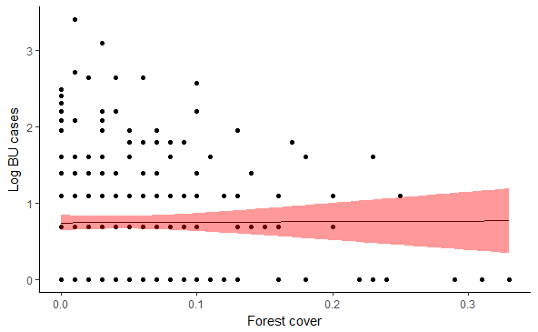

```r
#rename and get ready to plot
names(newdat3)[names(newdat3)=="0.975quant"] <- "Hi"
names(newdat3)[names(newdat3)=="0.025quant"] <- "Lo"
ggplot()+geom_point(data = bu, aes( Forest, BU_TOT.l)) +
  xlab("Forest cover")+ylab("Log BU cases") +
  geom_line(data = newdat3, aes(Forest, mean )) +
  geom_ribbon(data = newdat3, aes(Forest, ymax = Hi, ymin = Lo), fill = "red", alpha = 0.4) +
  theme_classic()
```

```r
#looks the same!
```

plot all together

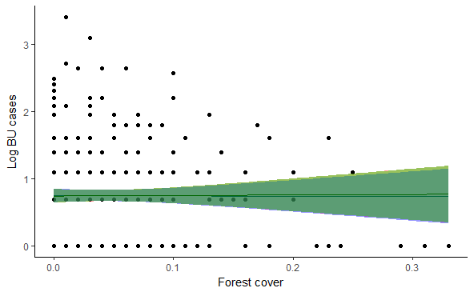